# Unit 1. Introduction to Causal Inference

UAB, 16-18 June, 2021

## What is causal inference?

- Inferring the effects of any treatment/policy/intervention/etc.
  - schooling on earnings
  - training programs on unemployment
  - class size on students’ performance
  - subsidies on firms’ investment, etc.
- “Credible” causal inference is essential to scientific discovery and your career
- Correlation does NOT imply causality
  - Reverse causality
  - Confounding association
  - [Spurious relation](https://www.tylervigen.com/spurious-correlations)

## The Counterfactual Framework

- Health status (from 1 to 5) from National Health Interview Survey (NHIS) 2005.
- What do we measure when comparing health outcomes for the hospitalized and the non-hospitalized?

  | Group | Sample Size | Mean Health Status | Std. Error |
  | --- | --- | --- | --- |
  | Hospital | 7,774 | 3.21 | 0.014 |
  | No hospital | 90,049 | 3.93 | 0.003 |

- If correlation does not imply causation, what does imply causation?
- We need to think in terms of **counterfactuals** (“the road not taken”)

## Potential outcomes

- Treatment

\[ \small D_i=\begin{cases} 1, & \text{if unit } i \text{ received the treatment (hospital)} \\ 0, & \text{otherwise.} \end{cases} \]

- Potential outcomes **if** the individual had received treatment or not (irrespective of actual treatment status) \[ \small \begin{matrix} Y_{i}(0) & \text{is the potential outcome for unit } i \text{ with } D_i = 0\\ Y_{i}(1) & \text{is the potential outcome for unit } i \text{ with } D_i = 1 \end{matrix} \]
- Observed outcome, under the Stable Unit Treatment Value Assumption (SUTVA)

\[ \small \begin{align*} Y_i &= Y_{i}(1) D_i + Y_{i}(0) [1-D_i] \\ &= Y_{i}(0) + [ Y_{i}(1) - Y_{i}(0) ] D_i \end{align*} \]

## The Fundamental Problem of Causal Inference

- Individual treatment effect:

\[ \tau_i = \color{red}{Y_{i}(1) - Y_{i}(0)} \]

- It is logically impossible to identify the causal effect for an individual, because we cannot observe *both* \(Y_{i}(1)\) and \(Y_{i}(0)\)
- In other words, there is no counterfactual evidence of treatment
  - when \(i\) goes to the hospital, we don’t observe her health status if she had not gone
  - when \(i\) does not go the hospital, what could have happened if she had gone?

## Treatment Effects

- Implication of the Fundamental Problem:

> *We must always make assumptions to identify at least the average causal effect for the population or for some relevant sub-groups*
- Average treatment effect (ATE)

\[ \small \mathbb{E}[\tau_i] = \mathbb{E}[Y_{i}(1)-Y_{i}(0)] = \mathbb{E}[Y_{i}(1)]-\mathbb{E}[Y_{i}(0)] \]

- Average treatment effect for the treatment group (ATT)

\[ \small \mathbb{E}[\tau_i | D_i=1] = \mathbb{E}[Y_{i}(1)-Y_{i}(0)| D_i=1] = \mathbb{E}[Y_{i}(1)| D_i=1]-\mathbb{E}[Y_{i}(0)| D_i=1] \]

## Selection Bias

- A naive and misleading estimand for ATE

\[ \small \begin{aligned} \mathbb{E}\left[Y_{i} | D_{i}=1\right]-\mathbb{E}\left[Y_{i} | D_{i}=0\right] &=\underbrace{\mathbb{E}\left[Y_{i}(1) | D_{i}=1\right]-\mathbb{E}\left[Y_{i}(0) | D_{i}=1\right]}_{\text{ATT}} \\ &+ \underbrace{\mathbb{E}\left[Y_{i}(0) | D_{i}=1\right]-\mathbb{E}\left[Y_{i}(0) | D_{i}=0\right]}_{\text{selection bias}} \end{aligned} \]

> **Causal inference is mostly about eliminating selection-bias**

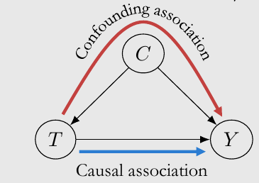

- Recall: correlation does not imply causation

## Random Assignment: the Ignorability assumption

- In a randomized controlled trial (RCT), subjects are *randomly* allocated into the treatment and control groups under study.
- Random assignment (RA) of treatment \(D_i\) makes treatment \(D_i\) *independent* of potential outcomes \[ \small \color{red}{RA \Rightarrow \{Y_{i}(0),Y_{i}(1)\} \perp D_i} \]
- This is also called “ignorability” or “exchangeability” of treatment

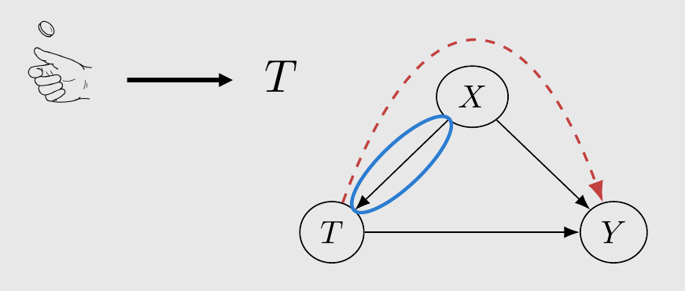

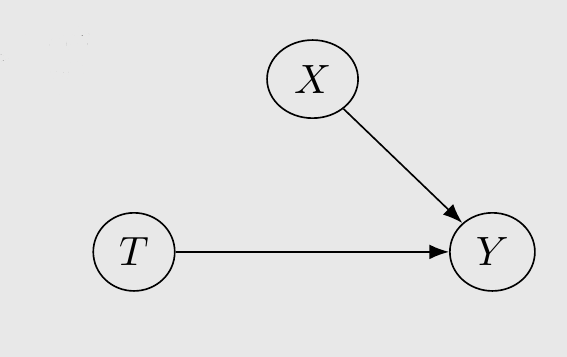

## Random Assignment solves the selection bias

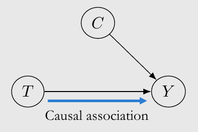

- Treatment does not have a causal “parent”
- Treatment and control groups are comparable: same observables and unobservables characteristics (on average) \(\Longrightarrow\) proper counterfactual
- The selection bias term vanishes: \[ \small \mathbb{E}\left[Y_{i} | D_{i}=1\right]-\mathbb{E}\left[Y_{i} | D_{i}=0\right] = ATE = ATT \]

## Estimating Causal Effect with Regression

- Assume for now that the treatment effect is constant:

\[ \small \color{red}{\tau = Y_{i}(1)-Y_{i}(0)},\quad \forall i \]

- Then, the observed outcome \(\small Y_i = Y_{i}(0) + D_i[Y_{i}(1) - Y_{i}(0)]\) can be written as \[ \small \begin{aligned} Y_i &= Y_{i}(0) + \color{red}{\tau} D_i \\ &= \color{blue}{\mathbb{E}[Y_{i}(0)]} + \tau D_i + Y_{i}(0)\color{blue}{-\mathbb{E}[Y_{i}(0)]}\\ Y_i &= \alpha + \tau D_i + u_i \end{aligned} \]
  - where \(\small \alpha = \mathbb{E}[Y_{i}(0)]\)
  - and \(\small u_i = Y_{i}(0)-\mathbb{E}[Y_{i}(0)]\) (random component of \(\small Y_{i}(0)\)).
- NOTE that RA guarantees \(D\) is exogenous: \(\small \mathbb{E}[u_i|D_i]=\mathbb{C}ov(u_i,D_i)=0\)

## Internal and External Validity

- Internal validity considers whether the the causal relationship based on the method (eg. RCT) is warranted or not
  - Are there any systematic error in the analysis? Proper design, measurement of variables, etc.
  - Are the underlying assumption in our analysis valid?
  - Can we address or eliminate alternative explanation for the result?
- External validity checks to what extent the casual relationship observed in the study can be generalized
  - to what settings, groups or times can it be extrapolated?
  - did the research account for real world conditions or interactions?

## Internal and External Validity (cont’d)

- In RCT, internal validity relies on proper experimental design, specially randomization
  - A guide by Nobel Prize winners Esther Duflo and Michael Kremer [here](http://economics.mit.edu/files/806)
- Trade-off between internal and external validity, but internal validity is the prior consideration
- For any method, you NEVER “have” internal or external validity, only (indirect) evidence supporting it
  - Assumption underlying your identification strategy CANNOT be “proven”: eg., potential outcomes are independent of treatment status
  - BUT you can show that observable characteristics are balanced between both groups

## The Role of Covariates in RCT

1. Additional controls **increase precision** of estimated effect
2. Checking that randomization was successful in **balancing** both groups
   - One should not find any (statistical) difference between the estimates with and without covariates
3. Conditional random assignment: sometimes randomization is done conditional on some observables
   - Example: poor / non-poor
4. Exploring mechanisms and other sources of heterogeneity

\[ \small Y_i = \alpha + \beta D_i +\gamma X_{i} + \delta D_i X_i + v_i \]

## Social Experiments

- Experiments are regarded as “the gold standard” for program evaluation.
  1. Has the potential for overcoming selection bias
  2. Transparency, easy to explain
- The “ideal experiment” is a benchmark for identification of causal effect
- However, BUT it can be costly, unfeasible or ethically questionable

## Problems of Experiments

1. Attrition Bias
2. Demand Effect: people behave differently because they are part of an experiment.
3. Substitution Bias: control group members may seek substitutes for treatment.
4. Anticipation Effects
5. Indirect treatment
6. “Scaling-up”, general equilibrium effects
7. In general, external Validity

## Causal Inference in the Absence of Randomized Experiments

- In **observational studies**, treatments cannot be regardes as randomly assigned.
- Technically, the **Ignorability** or Independence Assumption is NOT satisfied

\[ \small \{Y_{i}(0),Y_{i}(1)\} \not\perp D_i \]

- Alternatives methods with observational data exist, including natural experiments and other econometric techniques
- These aim at getting as close as possible to a randomized experiment.
- Lalonde (1986) gives a provocative description of the mistakes when using observational data instead of experimental randomized data.

## Unconfoundedness

- One alternative to identify causal effects depends on the **Unconfoundedness** assumption

\[ \small \{Y_{1i}, Y_{0i}\} \perp D_i | {X}_i \]

- Here, treatment assignment is independent of potential outcomes **conditional** on observable \({X}_i\)
  - This is also known as conditional independence assumption
- Then, selection bias *disappears* after controlling for \({X}_i\): i.e., “selection-on-observable”
- A possible approach for controlling for \(X_i\) is by adding it to the regression.
- Differently from the RCT setting, here we must control for observable characteristics to identify the ATE.

## Standard Errors in practical applications

- Remember the variance-covariance of the estimated regression coefficient: \[ \small Var(\widehat{\beta})=(X'X)^{-1}(X'\Omega X) (X'X)^{-1} \]
  - \(\small X_{n\times (k+1)}\) is the data matrix (\(\small n= \#\) observations, \(\small k=\#\) regressors)
  - \(\small \Omega_{n\times n}\) variance-covariance matrix of the error
- Under no heteroscedasticity and no autocorrelation, \(\small \Omega=\sigma^2 I_{n}\) this simplifies to \(\small Var(\widehat{\beta})=\sigma^2 (X'X)^{-1}\)
- This assumption is not credible in a lot of applied work

## Robust Standard Errors

- With cross-sectional data, observations are independent but we must estimate \(n\) variances: \(\small \sigma_i ^2\)
- There exist many different way to estimate this, using the residual \(\small e_i\)

  | HC0: \(e_i^2\) | HC1: \(\frac{n}{n-k-1} e_i^2\) |
  | --- | --- |
  | HC2: \(\frac{e_i^2}{1-h_i}\) | HC3: \(\frac{e_i^2}{(1-h_i)^2}\) |
  | HC4: \(\frac{e_i^2}{(1-h_i)^\delta}\) |  |

where \(\small h_i\) are hat values from the hat matrix and \(\small \delta =\min\{4, \frac{nh_i}{k+1}\}\)

- The default choice of HC is different in different software

## Clustered Standard Errors

- In many applications, several individual observations belong to the same group.
- On the top of heteroskedasticity, we may have intraclass correlation
  - Eg. random assignment of student to classes of different sizes
  - Data are unlikely to be independent across observations within classes (same teacher, shocks to learning)
- It is important to decide at which level to cluster observations and how to account for a small number of clusters
  - Abadie, Athey, Imbens and Wooldridge (2017) [When Should You Adjust Standard Errors for Clustering?](https://www.nber.org/papers/w24003)
  - Cameron and Miller (2015) [A Practitioner’s Guide to Cluster-Robust Inference](http://cameron.econ.ucdavis.edu/research/Cameron_Miller_JHR_2015_February.pdf)

## Example: National Supported Work Demonstration

- Large-scale experimental employment program from March 1975 until June 1977 in the US.
  - one of the oldest RCT in Economics
- Designed for hard-to-employ individuals
- Goal: to prepare individuals for regular employment, reduce unemployment, and reduce criminal behavior